# Analysis of Credit Card Customer Behavior and Attrition

## 2. To find out the dimensions that explains most of the variance in the data and find the variables that strongly influence these dimensions using principle component analysis

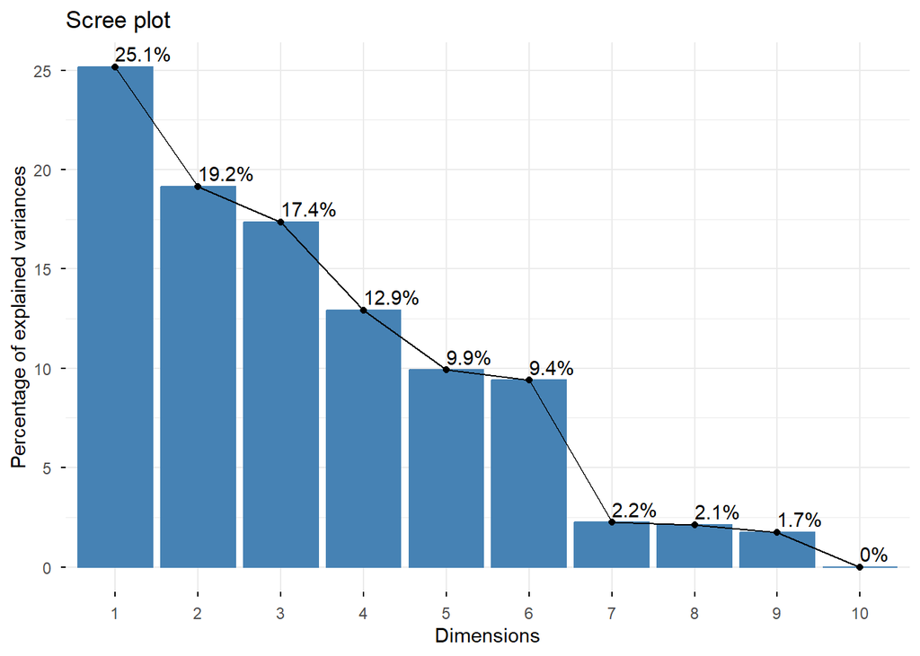

```r
df_sample = df[ , c(3,10,12,13,14,15,16,18,19,21)]
df_pca = prcomp(df_sample, scale. = T)

#plotting a screeplot
fviz_eig(df_pca, addlabels = T)
```

Dimension 1 explains 25.1% of all variance in the variables and dimension 2 explains 19.2% of all variance in the variables.

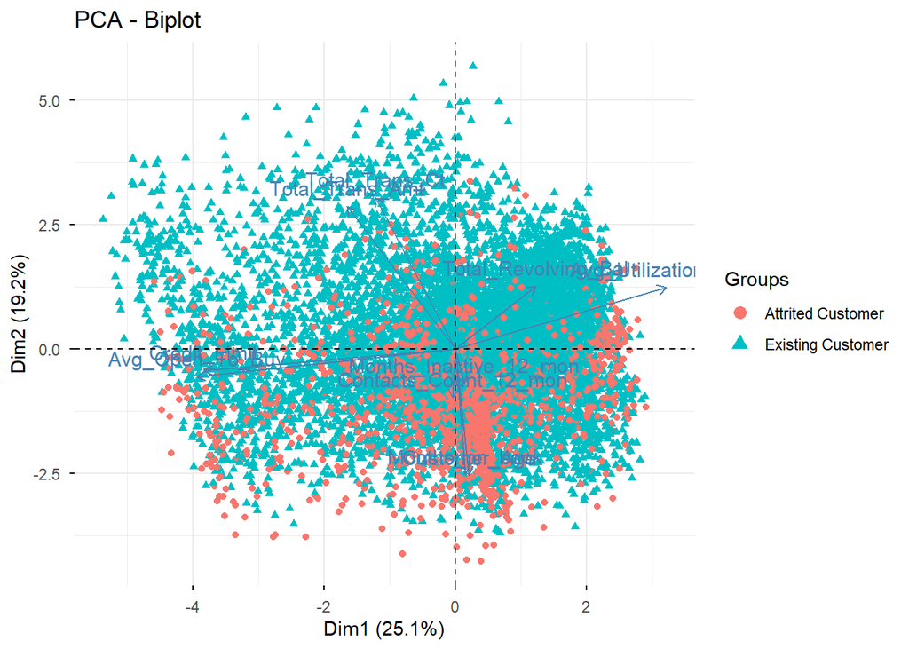

```r
#Biplot
fviz_pca_biplot(df_pca, label = "var", habillage = df$Attrition_Flag)
```

### Interpretations:

- Credit Limit, Average openness to purchase can strongly influence dimension 1
- Customer age, Months on book can strongly influence dimension 2